# matplotlib初级教程（Intro to pyplot）

#### axes()高度定制子图，以任意大小、在任意位置

函数原型：`matplotlib.pyplot.axes(arg=None, **kwargs)`  
Call signatures:  
`plt.axes()`  
`plt.axes(rect, projection=None, polar=False, **kwargs)`  
`plt.axes(ax)`  
参数说明：  
**arg**参数：{ None, 4-tuple, Axes }，此函数的行为根据arg参数取值类型的不同而不同：

- None：等同于`subplot(111, **kwargs)`
- 4-tuple of floats：form a rect = [left, bottom, width, height] that axes will be in.（rect的左下角位置以及宽高）
- Axes：等同于`plt.sca()`，即将arg参数所指axes设置为“当前axes”，同时隐含地改变axes的“父亲”，使“当前figure”对象为arg参数所指axes所在figure（此方法似乎不被推荐）

**projection**参数：{None, 'aitoff', 'hammer', 'lambert', 'mollweide', 'polar', 'rectilinear', str}, optional  
**polar**参数，布尔值，为True等同于“投影”设为'polar'  
**sharex,sharey**参数：Axes, optional，共享某axes的相同的x轴和y轴  
**label**参数：为所创建的axes设置标签  
**kwargs**关键字参数设置axes轴域的属性，当非默认投影时，可能还有其他关键字参数  
文档注解[Note](https://matplotlib.org/api/_as_gen/matplotlib.pyplot.axes.html#matplotlib.pyplot.axes)不明白

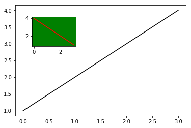

```python
plt.plot([1,2,3,4],color='black') # 这玩意儿画在subplot(111)上
plt.axes([.2,.6,.2,.2],facecolor='green') # 与上面的subplot在同一figure上
plt.plot([4,3,2,1],color='red')
```

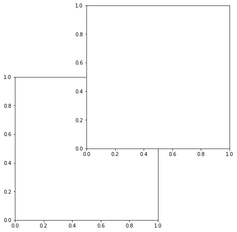

```python
plt.figure(figsize=(10,10))
plt.axes([0,0,.4,.4])
plt.axes([.2,.2,.4,.4])
```

### 网格、轴、刻度和标注

#### grid()用于设置网格线

函数原型：`matplotlib.pyplot.grid(b=None, which='major', axis='both', **kwargs)`  
参数说明：  
**b**：用于控制网格线的显示。b取True，表示显示网格，取False表示不显示网格，但是如果提供了任何kwargs关键字参数，则认为用户本意是希望显示网格线的，b参数失效。默认值None具有特殊效用：当参数b为None且未提供任何关键字参数时，grid(...)成为一个依据当前网格线状态执行打开或关闭网格线动作的"ON/OFF"开关，因此当我们仅仅想要显示原始的网格线而不做任何配置的时候，只需执行：`plt.grid()`，可代替：plt.grid(b=True)  
**which**：{'major', 'minor', 'both'}，指定要应用更改的是主刻度还是次刻度上的网格线，默认更改应用在主刻度上的网格线，当指定which为'both'或'minor'时要显示出效果，首先要打开次刻度上的网格线显示开关（`minorticks_on()`）  
**axis**：{'both', 'x', 'y'}，指定要应用更改的是x轴还是y轴上的网格线  
**kwargs**：kwargs关键字参数用于设置网格线的外观，其为Line2D对象属性。  
plt.minorticks_on()：  
在轴上显示小刻度（感觉比“次刻度”顺耳啊），但须知：显示小刻度可能会降低性能，如果绘图速度有问题，可以使用`minor ticks_off()`将其关闭

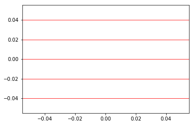

```python
# b参数
plt.plot()
plt.grid(True,c='red') # 打开，等同于plt.grid(c='red')
plt.grid() # 开关，刚才是打开状态，因此现在为关闭
plt.grid(b=None,axis='y') # 开关，刚才处于关闭状态，于是打开，等同于plt.grid(axis='y')，表示“显示”将只应用在y轴上的网格线
```

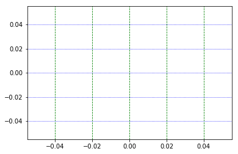

```python
# axis参数
plt.plot()
plt.grid(axis='y',c='blue',linestyle=':') # 更改应用在y轴上的网格线，颜色为蓝色，线条格式为‘某种’虚线
plt.grid(axis='x',c='green',linestyle='--') # 类同上
```

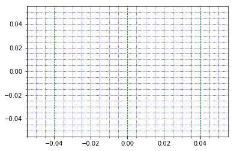

```python
# which参数
plt.plot()
plt.minorticks_on() # 打开次刻度上的网格线显示开关
plt.grid(which='both',c='blue',linestyle=':') # 将更改应用到全部x轴和y轴的主刻度和次刻度上去，蓝色
plt.grid(axis='x',c='green',linestyle='--') # 将更改应用到x轴上的主刻度（默认）上的网格线，绿色
```

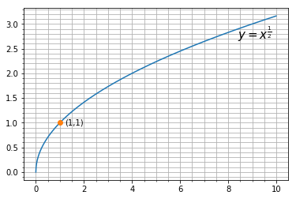

```python
x=np.arange(0,10,0.01)
plt.plot(x,np.power(x,0.5))
plt.plot([1],[1],marker='o') # 突出某一个点
plt.minorticks_on()
plt.grid(which='both') # 此时grid(...)充当“开关”，根据之前状态，现在是“开”，于是将“开”应用到“which”全部大小刻度上的网格线
plt.annotate('(1,1)',(1.2,0.95))
plt.annotate(r'$y=x^{\frac{1}{2}}$',(0.8,0.8),xycoords='figure fraction',fontsize=15) # (0.8,0.8)表示靠近右上角的位置，(0,0)表示左下角，(0.5,0.5)表示中央位置
```

#### axis()用于获取或设置轴的相关属性

函数原型：`matplotlib.pyplot.axis(*v, **kwargs)`  
Call signatures:  
`xmin, xmax, ymin, ymax = axis()`  
`xmin, xmax, ymin, ymax = axis(xmin, xmax, ymin, ymax)`  
`xmin, xmax, ymin, ymax = axis(option)`  
`xmin, xmax, ymin, ymax = axis(**kwargs)`  
xmin, ymin, xmax, ymax 是可选的float类型参数，用于设置坐标轴的范围或者说视区，要么不设置要么必须全部给出。  
其他参数（看不懂，艹你LM）  
注：一个常见的需求是，你希望图案所在的轴域的x和y轴是等宽比例显示的，你只需要执行`plt.axis('equal')`，如果同时设置轴域范围，则：

```
plt.axis('equal')
plt.axis([xmin,xmax,ymin,ymax])
```

注意顺序不要颠倒哦

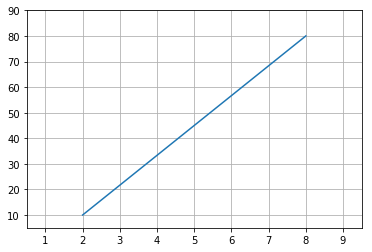

```python
plt.plot(range(2,9),np.linspace(10,80,7))
plt.axis([0.5,9.5,5,90]) # 实际上是[1,10,10,90]，WHY？
plt.grid()
```

#### 有时我们比较关心轴域的实际的边界值，你知道的，譬如上面这幅图，xlim=1,xmax=9，但是实际轴域的x轴范围不是[1,9]，还要大一点，你可以看见刻度1的左边留有空白，刻度9的右边留有空白，我们可以使用plt.gca().get_xbound()和plt.gca().get_ybound()获取轴域的实际边界范围

#### xlim()和ylim()获取或设置当前axes的x或y轴的上下限

函数原型（以xlim()为例）：`matplotlib.pyplot.xlim(*args, **kwargs)`  
Call signatures：  
`left, right = xlim()` # return the current xlim，相当于对当前axes调用get_xlim()  
`xlim((left, right))` # set the xlim to left, right  
`xlim(left, right)` # set the xlim to left, right  
可以通过关键字参数只设置某一边限：  
`xlim(right=3)` # adjust the right leaving left unchanged  
`xlim(left=1)` # adjust the left leaving right unchanged  
对于ylim()，相应的关键字参数则是：`top`和`bottom`  
xlim(...)设置限制将关闭x轴的自动缩放（Setting limits turns autoscaling off for the x-axis.）（什么意思）

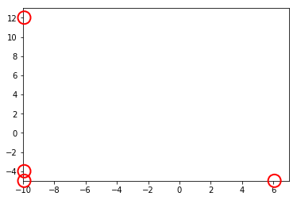

```python
plt.xlim(-10,7)
plt.ylim(5,13)
plt.ylim(bottom=-5)
# 朱笔画圈
plt.text(-10,11.77,' ',bbox=dict(boxstyle='circle',ec='r',fc='white',linewidth=2,fill=False)) # 还有其他好办法吗？见./patches与path.ipynb#画圆
plt.text(-10,-4.25,' ',bbox=dict(boxstyle='circle',ec='r',fc='white',linewidth=2,fill=False))
plt.text(-10,-5.25,' ',bbox=dict(boxstyle='circle',ec='r',fc='white',linewidth=2,fill=False))
plt.text(6,-5.25,' ',bbox=dict(boxstyle='circle',ec='r',fc='white',linewidth=2,fill=False)) # 好蠢啊，应该写个for循环的。。
```

#### xticks()和yticks()用于设置轴刻度和刻度标签

函数原型（以xticks()为例）：`matplotlib.pyplot.xticks(ticks=None, labels=None, **kwargs)`  
Call signatures:  
`locs, labels = xticks()` # Get locations and labels，等同于在axes对象上调用 get_xticks() 和 get_xticklabels() 方法  
`xticks(ticks, [labels], **kwargs)` # Set locations and labels，等同于在axes对象上调用 set_xticks() 和 set_xticklabels() 方法  
刻度标签labels参数是可选的  
关键字参数kwargs用于设置标签labels（Text labels）的外观属性（Text properties can be used to control the appearance of the labels.）  
`xticks([])`禁用轴刻度及标签

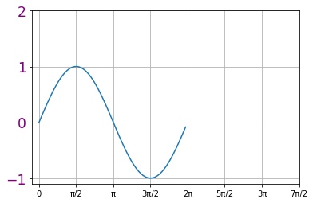

```python
x=np.arange(0,2*np.pi,0.1)
y=np.sin(x)
plt.plot(x,y)
plt.xticks(np.arange(0,4*np.pi,0.5*np.pi),[0,'π/2','π','3π/2','2π','5π/2','3π','7π/2','4π']) # labels可以长于或短于ticks，当较短时，则有些刻度无标签，当较长时，则进行截取
plt.yticks([-1,0,1,2],color='purple',fontsize='xx-large')
#plt.xticks([])
plt.grid()
```

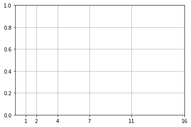

```python
# 和axis()设置刻度的区别：axis()只能设置轴最小和最大刻度，且刻度均匀，而xticks()和yticks()可以设置全部刻度，想怎么细分就怎么细分，任意设置
plt.xticks([1,2,4,7,11,16]) # 设置不均的刻度
plt.grid()
```

#### spines配置axes的脊柱（坐标系）

直观上，脊柱就是我们的axes的四个框框，特别是左边框和下边框都是有刻度的，也就是纯粹意义上的“直角坐标系”，平时所见手绘的直角坐标系都是位于中央，很容易设置，为了将脊柱放在图的中间，我们必须将其中的两条（上和右）设置为无色或者隐去，然后调整剩下的两条到合适的位置——至数据空间的 0 点

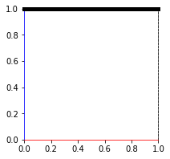

```python
# 脊柱颜色
plt.figure(figsize=(3,3))
plt.subplot()
ax=plt.gca()
ax.spines['left'].set_color('blue')
ax.spines['bottom'].set_color('red')
# 脊柱宽度
ax.spines['top'].set_linewidth(5)
# 脊柱类型
ax.spines['right'].set_linestyle('--')
```

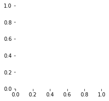

```python
# 去掉脊柱
plt.figure(figsize=(3,3))
ax=plt.subplot()
ax.spines['top'].set_visible(False) # 隐去上边框
ax.spines['bottom'].set_visible(False) # 隐去下边框
ax.spines['left'].set_visible(False) # 隐去左边框
ax.spines['right'].set_visible(False) # 隐去右边框
```

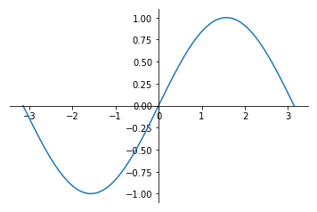

```python
# 移动脊柱
ax=plt.subplot()
x=np.linspace(-np.pi,np.pi,100)
y=np.sin(x)
plt.plot(x,y)
ax.spines['left'].set_position(('data',0)) # 'data'表示“数据空间”
ax.spines['bottom'].set_position(('data',0))
ax.spines['top'].set_visible(False) # 上边框隐去
ax.spines['right'].set_color(None) # 右边框无色
```

#### text()在轴域上添加说明文本

函数原型：`matplotlib.pyplot.text(x, y, s, fontdict=None, withdash=False, **kwargs)` 参数说明：  
参数x,y指定文本的放置位置，实际上是指定文本左下角的位置坐标，默认其是在当前绘制的数据坐标系（data coordinates）中，也可以转换为其他坐标系，譬如可以指定文本是在“轴坐标系”（axis coords）中（通过给定关键字参数transform进行设置），x=0,y=0表示左下角，x=1,y=1表示右上角，x=0.5,y=0.5表示中心。  
参数s指定要显示的说明文本  
参数fontdict，一个可选的字典参数，用于覆盖默认的Text属性，fontdict默认取值为None，此时Text属性由`rc`参数决定（rc是什么？）  
参数withdash为True时，表示创建一个TextWithDash实例而不是Text实例（What？），默认为False  
kwargs关键字参数用于其他设置文本Text的选项，其为Text属性

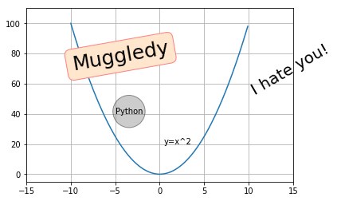

```python
x=np.arange(-10,10,0.1)
y=x*x
plt.plot(x,y)
plt.axis([-15,15,-5,110])
plt.grid()
plt.text(0.5,20,'y=x^2') # a simple example
plt.text(10,80,'I hate you!',fontsize=20,rotation=30)
plt.text(-10,80,'Muggledy',fontsize=25,bbox=dict(boxstyle="round",ec=(1.,0.5,0.5),fc=(1.,0.9,0.8)),rotation=10) # bbox设置注释框，ec是边框颜色，fc是内部颜色
plt.text(-5,40,'Python',bbox=dict(boxstyle='circle',facecolor='gray',alpha=0.4)) # simple
```

```python
# transform参数：转为“axis coords”
plt.text(0.5,0.5,'Center Country',horizontalalignment='center',verticalalignment='center',transform=plt.gca().transAxes,fontsize=25) # horizontalalignment可以简写为"ha"，verticalalignment可以简写为"va"
# 要使文本在正中，ha和va参数必不可少，尝试去掉就明白了，因为默认情况下的居中是以文本的左下角居中
```

[figure not shown]

#### [annotate()](https://matplotlib.org/api/_as_gen/matplotlib.pyplot.annotate.html#matplotlib.pyplot.annotate)可以实现同于text()的文字标注功能，这从其函数名就显而易见了，但最鲜明的区别是annotate()可以绘制箭头

函数原型：`matplotlib.pyplot.annotate(s, xy, *args, **kwargs)`  
参数说明：  
**xy**参数是一个二元组，表示被注释的点的位置坐标(x,y)，实现最简单的应用：annotate(s,xy)，即“用s标注点(x,y)”。当仅用于该用途时，(x,y)就是标注文本的左下角坐标。  
**xytext**是一个二元组，可选参数，表示注释文本的位置坐标，默认与xy值相同，和xy参数一起用以配合arrowprops参数设置指向箭头。其中xy表示箭头位置坐标，xytext表示箭尾位置坐标，在arrowprops的字典中无arrowstyle键时，确实是这样，如果通过arrowstyle设置箭头，那么还可以以xy为箭尾，以xytext为箭头。  
箭头：  
**arrowprops**参数是一个字典，若不包含arrowstyle键，则以下键是允许的： `width`（箭宽）、 `headwidth`（箭头宽）、 `headlength`（箭头长）、 `shrink`（箭的两端收缩总长的一部分（百分制），用来控制标注和箭两端之间小的空隙）、 `?`（Any key to matplotlib.patches.FancyArrowPatch）； 否则，arrowprops字典中不能含有前述键，arrowstyle键的取值为：'-'、'->'、'-['、'|-|'、'-|>'、'<-'、'<->'、'<|-'、'<|-|>'、'fancy'、'simple'、'wedge'，其他有效的键还可以是（参考[译](https://blog.csdn.net/leaf_zizi/article/details/82886755)文）： connectionstyle （the connection style）、 relpos （default is (0.5, 0.5)）、 patchA （default is bounding box of the text）、 patchB （default is None）、 shrinkA （default is 2 points）、 shrinkB （default is 2 points）、 mutation_scale （default is text size (in points)）、 mutation_aspect （default is 1.）、 ? （any key for [matplotlib.patches.PathPatch）](https://matplotlib.org/api/_as_gen/matplotlib.patches.PathPatch.html#matplotlib.patches.PathPatch)  
**xycoords**可选参数，可以是str, Artist, Transform, callable 或 tuple。该参数用于设置参数xy所处的坐标系，之前在text()中已经初步接触过data coordinates和axis coords，这里我也不想多说，实在看不下去这破文档了，我只提一下xycoords参数可取的一个字符串值："polar"，表示“极坐标系”，有一点很奇怪的是：如果当前plot本身就是极坐标系（polar coords），那么再使用该参数并设置为"polar"就会出错，但如果当前plot是直角数据坐标系（data coords），那么指定xycoords='polar'就可以正常工作  
**textcoords**可选参数，可以是str, Artist, Transform, callable 或 tuple。该参数用于设置参数xytext所处的坐标系，其取值同xycoords，并且还允许两种属性值：'offset points'（相对于被注释点xy的偏移量（单位是点））和'offset pixels' （相对于被注释点xy的偏移量（单位是像素））  
**kwargs**关键字参数用于其他设置Text文本外观选项

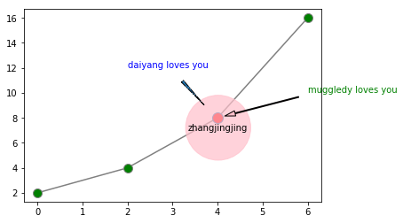

```python
x=[0,2,4,6]
y=[2,4,8,16]
plt.plot(x,y,marker='o',markersize=10,c='gray',markerfacecolor='green')
plt.plot([4],[8],marker='o',markersize=12,markerfacecolor='red')
plt.annotate('zhangjingjing',(3.35,7),bbox=dict(boxstyle='circle',facecolor='pink',ec='pink',alpha=0.7)) # 如何画心形注解框？
plt.annotate('muggledy loves you',(4,8),(6,10),arrowprops=dict(facecolor='pink',shrink=0.08,width=1,headwidth=6),color='green') # shrink收缩箭长的8%
plt.annotate('daiyang loves you',(3.9,8.25),(2,12),arrowprops=dict(arrowstyle='wedge',linestyle='-.',shrinkA=15,shrinkB=15),color='blue') # shrinkA和shrinkB设置箭两端的缩进，单位为points，注意和上一行代码中的shrink是不一样的，linestyle键出自“？”（ matplotlib.patches.PathPatch）
```

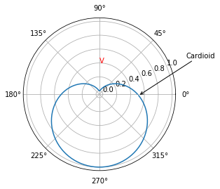

```python
plt.subplot(111,polar=True) # 当前plot本身是极坐标系
#plt.grid() # 默认极坐标就是显示网格线的，所以执行plt.grid()会关闭它
plt.annotate('V',xy=(0.5*np.pi,0.4),color='red') # plt.annotate('V',xy=(0.5*np.pi,0.4),xycoords='polar',color='red')出错，注释掉第一行代码就正确了
# 绘制心形线：ρ=a(1-cosθ)
theta=np.arange(0,2*np.pi,0.05) # θ
p=0.5*(1-np.sin(theta)) # ρ
plt.plot(theta,p)
plt.annotate('Cardioid',xy=(theta[-1],p[-1]),xytext=(theta[8],p[8]+1),arrowprops=dict(arrowstyle='->'))
```

#### title()用于设置axes的大标题，有三个可选项：位于中央、与左边缘对齐、与右边缘对齐

函数原型：`matplotlib.pyplot.title(label, fontdict=None, loc='center', pad=None, **kwargs)`  
参数说明：  
**label**参数是标题文本  
**fontdict**参数是一个控制标题外观的字典，默认值为：{'fontsize': rcParams['axes.titlesize'], 'fontweight' : rcParams['axes.titleweight'], 'verticalalignment': 'baseline', 'horizontalalignment': loc}  
**loc**参数：{'center', 'left', 'right'}  
**pad**参数设置标题与axes顶部的距离，单位为points，默认值为rcParams['axes.titlepad']  
**kwargs**关键字参数设置其他Text文本外观属性

#### suptitle()为figure设置一个居中的大标题

函数原型：`matplotlib.pyplot.suptitle(t, **kwargs)`  
参数说明：  
**t**参数：标题文本  
**x**参数：float, default 0.5，表示的是在figure coordinates下文本的x坐标，是一个figure fraction分数（百分比）  
**y**参数：float, default 0.98，表示的是在figure coordinates下文本的y坐标  
**horizontalalignment,ha**参数：{'center', 'left', right'}, default: 'center'，标题文本相对于(x,y)的水平对齐方式，默认为'center'，表示文本的中心正处于位置(x,y)，'right'表示文本的右端处于(x,y)位置  
**verticalalignment,va**参数：{'top', 'center', 'bottom', 'baseline'}, default: 'top'，类同上  
**fontsize,size**参数：default: rcParams["figure.titlesize"]  
**fontweight,weight**参数：default: rcParams["figure.titleweight"]  
**fontproperties**参数：None or dict, optional 字典？怎么用？  
其他**kwargs**关键字参数，用于设置matplotlib.text.Text

```
[]
```

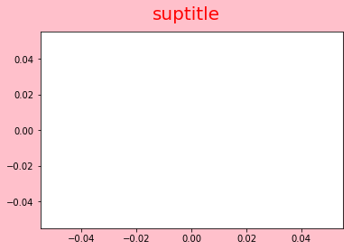

```python
plt.figure(facecolor='pink') # plt.gcf().set_facecolor('pink')
plt.suptitle('suptitle',x=0.5,y=0.98,color='red',size=20)
plt.plot()
```

#### xlabel()和ylabel()为x或y轴设置轴标签

函数原型（以xlabel为例）：`matplotlib.pyplot.xlabel(xlabel, fontdict=None, labelpad=None, **kwargs)`  
参数说明：  
**xlabel**参数设置标签文本  
**labelpad**参数设置标签与x轴之间的间距  
**kwargs**关键字参数设置标签文本Text外观

#### [legend()](https://matplotlib.org/api/_as_gen/matplotlib.pyplot.legend.html#matplotlib.pyplot.legend)可以为axes中出现的每一种线条或点添加一一对应的旗帜鲜明的注解

函数原型：`matplotlib.pyplot.legend(*args, **kwargs)`  
Call signatures:  
`legend()`  
`legend(labels)`  
`legend(handles, labels)`  
注：以上三种调用方式，对于完全的MATLAB风格编程者来说，只能使用第一种，后两种用于面向对象。其他可选参数：  
**loc**参数设置legend的位置，主要记住6种可取值：  
`字符串 代码`  
`'best' 0`  
`'upper right' 1`  
`'upper left' 2`  
`'lower left' 3`  
`'lower right' 4`  
`center 10`  
可取值'best'并不受推荐，当存在大量数据的绘图时，可能拖慢速度。  
loc参数可取一个二元组，(0,0)表示左下角、(0.5,0.5)表示中央、(1,1)表示右上角（实际上就是"figure fraction"类型值），二元组允许你更改legend所在的任意位置（在这种情况下，`bbox_to_anchor`将被忽略）  
**bbox_to_anchor**参数，可取值： BboxBase, 2-tuple 或 4-tuple of floats.  
这玩意儿配合loc参数使用，且只当loc参数不使用二元组时起效，bbox_to_anchor用来选取一个指定区域（一个长方形区域），然后由loc在此区域中定位legend的放置位置（左上、右上、坐下、右下、最佳等）。举例说，假使我们面前有一个分为四个象限的直角坐标系，我们可以指定右下象限为legend的放置区域，当指定loc为'upper left'时候，legend就出现在右下限区域的左上角。bbox_to_anchor参数的取值，可以是一个四元组，含义为：(x, y, width, height)，x,y,width,height的取值为"figure fraction"（一个分数、表示百分比），x,y表示长方形区域的左下角坐标，指定右下象限方形区域：(0.5,0,0.5,0.5)，x=0.5和width=0.5表示x轴长的一半、y=0那就是0，height=0.5表示y轴长的一半  
bbox_to_anchor参数的取值，还可以是一个二元组(x,y)（仍为"figure fraction"），配合loc，若loc为'lower left'，表示：legend框的左下角的位置为(x,y)，若loc为'upper right'，表示：legend框的右上角位于(x,y)位置处。  
其他参数见文档（例见"Nested pie charts"）  
第一种调用方式并不能满足需求，它只能工作在，每次plot()只绘制一条线且设置label的情况下，如果我们一次性在plot()中绘制了多条线，这时候，怎么为每一条线分别设置label呢？第一种解决办法就是通过内省机制`setp()`来完成；第二种，在线条对象上直接调用`set_label()`方法；第三种就是我们legend()的第二和第三种调用方式。  
第二种，首先获取要设置标签属性的线条所在的axes轴域对象，然后在该axes上调用legend()，传入标签列表，其顺序与plot中线条绘制的顺序一致：`axes.legend(['label 1','label 2',...])`  
第三种，更加灵活，接受两个参数，第一个是全部要设置标签属性的对象列表，第二个是对应的标签列表

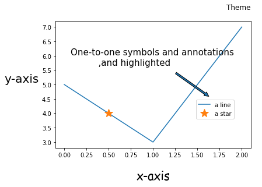

```python
plt.xlabel('x-axis',labelpad=20,fontfamily='fantasy',fontsize=20)
plt.ylabel('y-axis',labelpad=35,fontfamily='sans-serif',fontsize=20,rotation='horizontal')
plt.title('Theme',loc='right',pad=20)
plt.plot([5,3,7],label='a line') # legend中显示的文本将自动从此获取，姑且认为legend的文本为线条的label
plt.plot([0.5],[4],marker='*',markersize=15,label='a star',linestyle='')
plt.legend(loc=(0.72,0.23))
plt.annotate('One-to-one symbols and annotations \n          ,and highlighted',xy=(0.8,0.48),xycoords='figure fraction',xytext=(0.27,0.65),arrowprops=dict(arrowstyle='simple',shrinkA=15),fontsize=15)
```

```python
# 绘制正圆：x^2+y^2=4
x=np.arange(-2,2.01,0.01) # 由于arange()不包含end，所以end应设为end+step，通常我们用linspace：np.linspace(-2,2,100)
y=np.sqrt(np.fabs(4-x*x)) # fabs()绝对值不可省略，因为存在计算精度误差的问题，所以理论上可行而实际不可行，按理说是不需要fabs()的
plt.plot(x,y,c='black',label='a circle')
plt.plot(x,-y,color='black')
plt.legend(loc='upper right',bbox_to_anchor=(0.5,0.,0.5,0.5))
plt.annotate('Ellipse?',(0,0),ha='center',va='center',fontsize=20) # 使文本处于正中央，其中(0,0)是"data coords"
plt.annotate('How To Solve It?',(0,0),(1,1),arrowprops=dict(arrowstyle='simple',shrinkA=20,shrinkB=40),color='red',fontsize=25)
plt.axvline() # 沿轴垂线，参见spines移动脊柱，实际上，我本就是要的这种效果，但此前并不知道spines
plt.axhline() # 沿轴水平线
plt.annotate('right lower quadrant',(1,-1),(1.5,-1.8),arrowprops=dict(arrowstyle='simple',facecolor='pink',shrinkA=20),color='red',fontsize=15)
plt.fill([0,2,2,0],[-2,-2,0,0],color='gray')
```

[figure not shown]

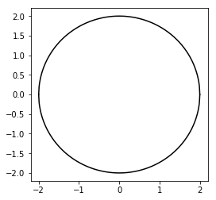

```python
# 解决：通过设置figure size可以使其“正”一点，还有其他办法吗？另一种办法是执行命令：plt.axis('equal')，具体请移步"plt.axis()"部分
plt.figure(figsize=(4,4)) # 在旧电脑上（2011年产）出现的问题：若取(4,4)还是显得扁了点，所以取(4,5)，大概是因为显示器的问题？
x=np.arange(-2,2.01,0.01)
y=np.sqrt(np.fabs(4-x*x))
plt.plot(x,y,c='black',label='a circle')
plt.plot(x,-y,color='black')
```

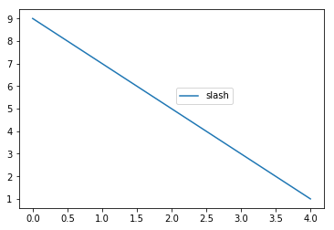

```python
plt.plot([9,7,5,3,1],label='slash')
plt.legend(loc='lower left',bbox_to_anchor=(0.5,0.5)) # legend框的左下角出现在(0.5,0.5)位置
```

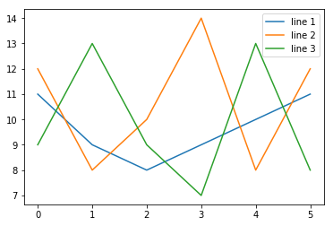

```python
index=range(6)
lines=plt.plot(index,np.random.randint(5,15,6),index,np.random.randint(5,15,6),index,np.random.randint(5,15,6))
ax=plt.gca()
labels=['line 1','line 2','line 3']
# 第二种调用方式
#ax.legend(labels)
# 第三种调用方式
plt.legend(lines,labels)
```

##### plt.getp()（'get property'）和plt.setp()（'set property'）用于获取和设置对象属性（对对象进行自省）

函数原型：`matplotlib.pyplot.setp(obj, *args, **kwargs)`  
譬如要将线条的linestyle属性设置为虚线，可以这么做：  
`line,=plt.plot([1,2,3])`  
`plt.setp(line,linestyle='--')`  
如果你想知道对象属性的有效值，可以提供该属性的名称：  
`plt.setp(line,'linestyle')`  
如果你想知道对象上的全部可设置的属性以及可取的值，可以：  
`plt.setp(line)`  
当控制台的定向输出（sys.stdout）因为某些原因而不可获得时，可以使用`file`关键字参数将结果定向输出到指定文件中：  
`with open('xxx.txt') as f: plt.setp(line,file=f)`  
setp()在单个实例或者实例的可迭代序列上操作，如果当前处于查询模式，即正在内省对象属性的可能取值，那么只使用序列中的第一个实例，如果是在设置对象属性，那么设置将在序列中的全部对象上生效  
setp()支持传递MATLAB风格的“属性字符串-值”对以及python的关键字参数，譬如以下是等效的：  
`plt.setp(lines,'linewidth',2,'color','red')` # MATLAB style  
`plt.setp(lines,linewidth=2,color='red')` # python style

###### 配置和修改对象的属性

在使用plt.plot()绘制线形图后，函数返回所绘线条对象。我们在plot()中传递了诸多线条属性用以控制生成的线条外观，但正如罗马不是一日建成的，线形图也可能需要几经修改，pyplot模块提供了必需的命令接口用以控制基本的外观属性的配置和修改，譬如xlim()、xticks()等，同时提供了对象方法用以控制全部的外观属性，在对象上配置和修改属性主要有三种方法：

- `obj.set_属性名(值)`
- `obj.set(属性名=值)`
- `plt.setp(对象,属性名=值)`

代码示例：

```
line = plt.plot(range(5))[0]
line.set_color('r')
line.set_linewidth(2.0)
# 或者：
line.set(color = 'g',linewidth = 2.0)
# 或者：
plt.setp(line, color = 'g',linewidth = 2.0)
```

对象属性使用`dir()`查看，对象文档使用`help()`

```
  linestyle: ['solid' | 'dashed', 'dashdot', 'dotted' | (offset, on-off-dash-seq) | ``'-'`` | ``'--'`` | ``'-.'`` | ``':'`` | ``'None'`` | ``' '`` | ``''``]
```

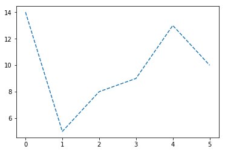

```python
lines=plt.plot(np.random.randint(5,15,6))
plt.setp(lines,linestyle='--')
plt.setp(lines,'linestyle') # 将列举出全部有效值（查询模式）
```

#### axvline()和axhline()绘制垂线（垂直于x轴）和水平线（与x轴水平）

函数原型：`matplotlib.pyplot.axvline(x=0, ymin=0, ymax=1, **kwargs)`  
axvline()：ax:axes,v:vertical  
参数说明：首先我们说明几个概念，在axis()中我们可以设置plot的x轴和y轴的刻度范围：xmin,xmax,ymin,ymax，于是平行于x轴的两条水平线y=ymin和y=ymax设置了axes（轴域）的“下边线”和“上边线”（我们姑且这么称呼哈），平行于y轴的垂线x=xmin和x=xmax设置了axes的“左边线”和“右边线”，xmax-xmin的值称为axes的“轴域宽”，ymax-ymin称为axes的“轴域高”。回到本函数中，参数x设置垂线的x轴坐标，参数ymin、ymax设置垂线的下端点和上端点相距于“下边线”的位置，取值为一个介于0到1的小数（百分比），譬如ymin取0，表示下端点距离下边线的距离为0，ymin取0.5表示下端点距离下边线的距离为“轴域高”的二分之一，ymax取0.9表示上端点距离下边线的距离为轴域高的0.9倍。  
函数原型：`matplotlib.pyplot.axhline(y=0, xmin=0, xmax=1, **kwargs)`  
axhline()：ax:axes,h:horizontal  
类同于axvline()的参数，axhline的参数y设置水平线的y轴坐标，xmin、xmax设置水平线的左端点和右端点相距于“左边线”的位置，譬如xmin取为0.5表示左端点距离左边线的距离为“轴域宽”的二分之一，xmax取值1表示右端点距离左边线的距离为一整个“轴域宽”。

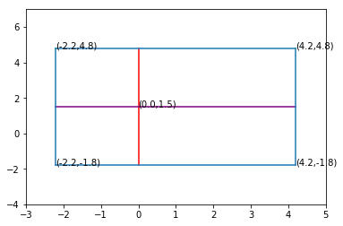

```python
xl,xr,yb,yt=plt.axis([-3,5,-4,7]) # x,y轴刻度范围
xlen=xr-xl # x轴长（轴域宽）
ylen=yt-yb # y轴长（轴域高）
p=ylen/2+yb # y轴中间位置
vl=plt.axvline(ymin=0.2,ymax=0.8,color='red') # 中间的那条垂线（红色）
hl=plt.axhline(p,xmin=0.1,xmax=0.9,color='purple') # 中间的那条水平线（紫色）
vlb,vlt=ylen*vl._y+yb # 计算vl线的下上端点在y轴上的坐标
hll,hlr=xlen*hl._x+xl # 计算hl线的左右端点在x轴上的坐标
plt.axvline(hll,ymin=0.2,ymax=0.8)
plt.axvline(hlr,ymin=0.2,ymax=0.8)
plt.axhline(vlb,xmin=0.1,xmax=0.9)
plt.axhline(vlt,xmin=0.1,xmax=0.9)
plt.annotate('({0:.1f},{1:.1f})'.format(0,p),(0,p)) # 显示位置坐标
plt.annotate('({0:.1f},{1:.1f})'.format(hll,vlt),(hll,vlt))
plt.annotate('({0:.1f},{1:.1f})'.format(hll,vlb),(hll,vlb))
plt.annotate('({0:.1f},{1:.1f})'.format(hlr,vlt),(hlr,vlt))
plt.annotate('({0:.1f},{1:.1f})'.format(hlr,vlb),(hlr,vlb))
```

#### hlines()可用于在全部y刻度处绘制多条水平线段，在任意位置起始，在任意位置结束（Plot horizontal lines at each y from xmin to xmax.）

函数原型：`matplotlib.pyplot.hlines(y, xmin, xmax, colors='k', linestyles='solid', label='', *, data=None, **kwargs)`  
参数说明：  
**y**参数：单个标量或者序列。譬如[y1,y2,...ym]，将绘制m条水平线段，所在直线分别为y=y1,y=y2,...,y=ym  
**xmin,xmax**参数指定每条线段的开头和结尾在x轴上的坐标，xmin和xmax可能是单个标量也可能是序列，这得看要绘制多少条水平线（一条的话就是单个标量），譬如第一条线段的开头x坐标为3，结尾为5，第二条开头为1，结尾为7，第三条开头为4，结尾为9，则xmin为[3,1,4]，xmax为[5,7,9]  
**color**参数可以设置每一条水平线的颜色，可以是一个序列  
**linestyles**参数：{'solid', 'dashed', 'dashdot', 'dotted'}, optional  
**label**参数：string, optional, default: ''  
**kwargs**关键字参数设置LineCollection属性

```python
plt.hlines([1,2,3,4,5],[1,2,3,4,5],[3,4,5,6,7],['red','green','blue','yellow','gray'],linestyles=['dashdot','solid','dashed','solid','dotted'])
```

[figure not shown]

#### vlines()可用于在全部x刻度处绘制多条垂直线段，在任意位置起始，在任意位置结束（Plot vertical lines at each x from ymin to ymax.）

函数原型：`matplotlib.pyplot.vlines(x, ymin, ymax, colors='k', linestyles='solid', label='', *, data=None, **kwargs)`  
参数见hlines()

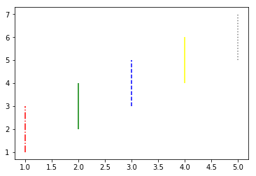

```python
plt.vlines([1,2,3,4,5],[1,2,3,4,5],[3,4,5,6,7],['red','green','blue','yellow','gray'],linestyles=['dashdot','solid','dashed','solid','dotted'])
```

### 区域填充

#### fill()用于填充指定多边形区域

函数原型：`matplotlib.pyplot.fill(*args, data=None, **kwargs)`  
参数说明：  
**args**可变位置参数：可以指定多组`x, y, [color]`的组合，color是可省的，注意顺序不要弄错。我们知道构成一个多边形区域的最初元素就是几个点，将点逐一连接于是就得到了一个多边形区域，这些点正是由x、y参数指定的，它们都是序列对象，x是全部点在x轴上坐标的有序集合，y是全部点在y轴上坐标的有序集合。连线的顺序为：从第一个点出发连接第二个点，再从第二个点出发连接第三个点，以此类推（理论上讲我们现在可以画任意图像了而不仅仅是简单几何图案），其中点的顺序由此确定：zip(x,y)，其得到一个二元组序列，每一个二元组表示一个坐标点，列表第一项就是第一个点，第二项就是第二个点，... 若不能构成封闭区域，那么总是自动将起点和终点以直线连接起来，由此构成封闭区域  
函数调用譬如：  
`fill(x,y)` # 确定一个多边形区域，填充颜色为default color  
`fill(x1,y1,x2,y2,'b')` # 确定两个多边形区域，其中第二个区域的颜色为蓝色  
**kwargs**参数设置Polygon属性  
data参数尚不清楚

星形线：$x^\frac{2}{3}+y^\frac{2}{3}=a^\frac{2}{3}$

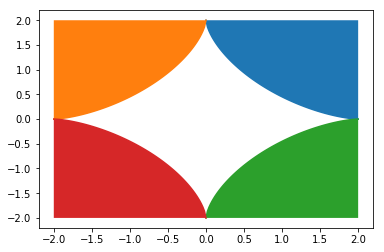

```python
# 绘制第一象限的星形线，根据对称性，得到其他象限星形线片段
a=2 # 取a为2
x=np.linspace(0,a,100)
y=np.power(np.power(2,2/3)-np.power(x,2/3),1.5)
plt.plot(x,y)
plt.plot(-x,y)
plt.plot(x,-y)
plt.plot(-x,-y)
# 填充四个边角区域
x1=np.concatenate((x,[2,0]))
y1=np.concatenate((y,[2,2]))
x2=np.concatenate((-x,[-2,0]))
y2=np.concatenate((y,[2,2]))
x3=np.concatenate((x,[2,0]))
y3=np.concatenate((-y,[-2,-2]))
x4=np.concatenate((-x,[-2,0]))
y4=np.concatenate((-y,[-2,-2]))
plt.fill(x1,y1,x2,y2,x3,y3,x4,y4)
```

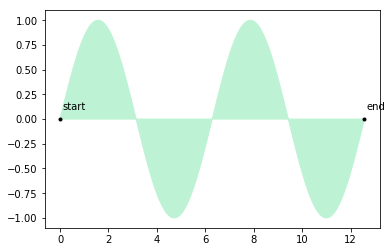

```python
# end终点和start起点直连才构成的封闭区域，填充它们完事儿
x=np.linspace(0,4*np.pi,500)
y=np.sin(x)
plt.fill(x,y,color='#bdf3d4')
plt.plot([x[0],x[-1]],[y[0],y[-1]],marker='.',color='black',linestyle='')
plt.annotate('start',(x[0]+0.1,y[0]+0.1))
plt.annotate('end',(x[-1]+0.1,y[-1]+0.1))
```

#### fill_between()用于对x（参数）范围之内两个函数曲线y1和y2之间（垂直）区域的颜色填充

函数原型：`matplotlib.pyplot.fill_between(x, y1, y2=0, where=None, interpolate=False, step=None, *, data=None, **kwargs)`  
默认y2=0，即填充x范围内曲线y1与x轴之间的区域。  
参数说明：  
**x**参数是两个函数共同的在x轴上点的取值集合，y1是函数曲线的对于自变量x的因变量的取值集合，y2同理。因此y1、y2和x的序列长度一致；特别地，y1和y2允许是标量，即单个整数值，这表示其为一条平行于x轴的水平线。  
**where**参数：array of bool (length N), optional, default: None  
where参数是一个条件阈值，接受一个条件表达式，返回结果应为一个一维布尔数组。含义：对于两个函数之间的区域，符合条件则填充，不符合则不填充。  
**interpolate**和**step**参数：不理解  
**kwargs**关键字参数用于设置其他 Polygon属性

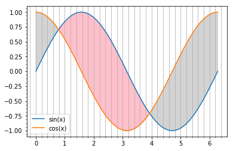

```python
x=np.linspace(0,2*np.pi,100)
y1=np.sin(x)
y2=np.cos(x)
sinx,cosx=plt.plot(x,y1,x,y2)
sinx.set_label('sin(x)') # 混合编程（分清主次）是最优的选择
cosx.set_label('cos(x)')
plt.legend()
plt.fill_between(x,y1,y2,where=y1<y2,color='lightgray')
plt.fill_between(x,y1,y2,where=y1>y2,color='pink')
plt.minorticks_on()
plt.grid(axis='x',which='both')
```

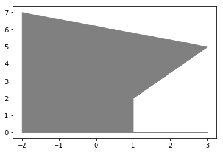

```python
# 这个语句最大的问题是，背离了函数的本意，即两个函数曲线之间区域的填充，重点是函数曲线，函数的自变量x的变化应总是向着x轴正方向的
plt.fill_between([1,3,-2],[2,5,7],color='gray') # 所以[1,3,-2]是不合理的，it will not be in line with expectation
# 另外我们可以看出，两条曲线是如何构成封闭区域的：将曲线1和曲线2的左端点连接起来，将曲线1和曲线2的右端点连接起来，于是构成的封闭区域
# 而其确定左右端点的依据，就是(x[0],y1[0]),(x[0],y2[0]),(x[-1],y1[-1]),(x[-1],y2[-1])
```

```
Text(2,0.398434,'$f(x)=\\frac{1}{\\sqrt{2\\pi}\\sigma}e^{-\\frac{(x-\\mu)^2}{2\\sigma^2}}$')
```

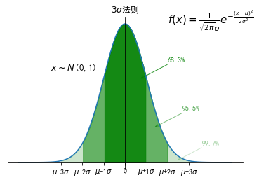

```python
# 绘制正态概率密度函数
mu=0
sigma=1
radius=5
x=np.linspace(mu-radius,mu+radius,100)
def f(x,mu,sigma):
    return 1/(np.sqrt(2*np.pi)*sigma)*np.power(np.e,-(np.power((x-mu),2)/2*np.power(sigma,2)))
y=f(x,mu,sigma)
ymax=np.max(y)
plt.plot(x,y)
ax=plt.gca()
ax.spines['left'].set_position(('data',0))
ax.spines['bottom'].set_position(('data',0))
ax.spines['top'].set_visible(False)
ax.spines['right'].set_visible(False)
plt.yticks([])
#plt.xticks([mu+i*sigma for i in range(-3,4)],[i for i in range(-3.4)]) # 以前考研的时候我是万分期待敲代码的时光，虽然我有一颗撞南墙的心，但是今天实在是太过痛苦，无穷无尽的挫败感，使我绝望，搞了一天pelican，不过想部署一下博客，结果一事无成，到处都是错误，昏了头了，艹
# 我是真的醉了，我花了老大的功夫，才找出上述代码的错误，简直不可想象，我甚至都开始觉得我TM还适合这个行业？我尼玛也太蠢了点。。。
plt.xticks([mu+i*sigma for i in range(-3,4)],['0' if i==0 else '$\mu$'+('+'+str(i) if i>0 else str(i))+'$\sigma$' for i in range(-3,4)])
mu_one_sigma=f(mu+sigma,mu,sigma)
mu_two_sigma=f(mu+2*sigma,mu,sigma)
mu_three_sigma=f(mu+3*sigma,mu,sigma)
plt.fill_between(x,y,where=y>=mu_one_sigma,color='g',alpha=0.8)
plt.fill_between(x,y,where=y>=mu_two_sigma,color='g',alpha=0.5)
plt.fill_between(x,y,where=y>=mu_three_sigma,color='g',alpha=0.2)
plt.title('$3\sigma$法则')
def cc(color,alpha):
    return mcolors.to_rgba(color, alpha)
plt.annotate('68.3%',(mu+(2/3)*sigma,(3/5)*ymax),(mu+2*sigma,(3/5)*ymax+0.05),arrowprops=dict(arrowstyle='->',fc='g',ec=cc('g',alpha=0.8)),color=cc('g',alpha=1))
plt.annotate('95.5%',(mu+(2/3)*2*sigma,(1/4)*ymax),(mu+2.7*sigma,(1/4)*ymax+0.05),arrowprops=dict(arrowstyle='->',ec=cc('g',alpha=0.5)),color=cc('g',alpha=0.7))
plt.annotate('99.7%',(mu+(4/5)*3*sigma,(1/100)*ymax),(mu+3.6*sigma,(1/1001/4)*ymax+0.05),arrowprops=dict(arrowstyle='->',ec=cc('g',alpha=0.2)),color=cc('g',alpha=0.4))
plt.annotate('$x\sim N$'+'({0},{1})'.format(mu,sigma),(mu-3.5*sigma,(2/3)*ymax),fontsize=13)
plt.annotate(r'$f(x)=\frac{1}{\sqrt{2\pi}\sigma}e^{-\frac{(x-\mu)^2}{2\sigma^2}}$',(mu+2*sigma,ymax),fontsize=15) # 靠，LaTeX加'r'原始字符串啊！忘
```

[figure not shown]

#### fill_betweenx()在y范围内对两个函数曲线（$y1=f(x)$和$y2=g(x)$）之间沿着水平方向的区域进行填充，这两个函数应该具有反函数（$x1=f^{-1}(y)$和$x2=g^{-1}(y)$），即y到x是一一映射的，否则区域填充将不符合预期

函数原型：`matplotlib.pyplot.fill_betweenx(y, x1, x2=0, where=None, step=None, interpolate=False, *, data=None, **kwargs)`  
默认x2为0，表示填充x1与y轴之间的区域  
该图像绘制，应以y为自变量，x为因变量，即首先写出反函数。  
参数说明类似fill_between()

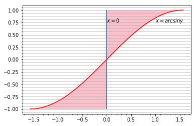

```python
x=np.linspace(-0.5*np.pi,0.5*np.pi,100)
y=np.sin(x)
plt.plot(x,y,color='red')
plt.fill_betweenx(y,x,color='pink')
plt.axvline(ymin=0.05,ymax=0.95)
plt.annotate('$x=0$',(0,0.75)) # matplotlib中任何Text文本都允许嵌入LaTeX表达式，但记得加上'r'原始字符串标识，这是因为排版公式时，字符串所包含的内容必须按照 TeX 的规范，而不是其他的规范，来进行解析。所以使用 raw string 可以避免其它规则解释字符串中某些特殊字符所带来的歧义。
plt.annotate(r'$x=arcsiny$',(1,0.75))
plt.minorticks_on()
plt.grid(axis='y',which='both')
```

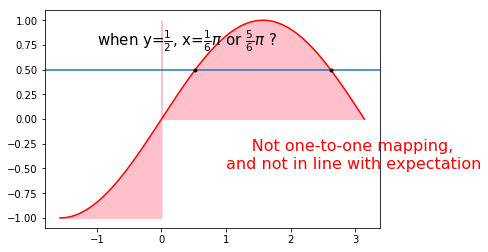

```python
x=np.linspace(-0.5*np.pi,np.pi,100)
y=np.sin(x)
plt.plot(x,y,color='red')
plt.fill_betweenx(y,x,color='pink')
plt.axhline(0.5)
plt.plot([(1/6)*np.pi,(5/6)*np.pi],[1/2,1/2],marker='.',color='black',linestyle='')
plt.annotate(r'when y=$\frac{1}{2}$, x=$\frac{1}{6}\pi$ or $\frac{5}{6}\pi$ ?',(-1,0.75),fontsize=15)
plt.annotate('     Not one-to-one mapping,\nand not in line with expectation',(1,-0.5),fontsize=16,color='r')
```

#### axvspan()添加垂直长方形区域用以高亮显示某一自变量跨度区间

函数原型：`matplotlib.pyplot.axvspan(xmin, xmax, ymin=0, ymax=1, **kwargs)`  
参数说明：  
**xmin,xmax**：标量，描述自变量跨度范围  
**ymin,ymax**：标量，可选，描述长方形的高度范围，默认xmin=0,xmax=1，一个分数（相对于axes高度的百分比），0-1，前者表示长方形底部位于axes底部，后者表示长方形顶部位于axes顶部，若ymax取值0.5，则长方形顶部位于axes中部

#### axhspan()添加水平长方形区域用以高亮显示某一因变量跨度区间

函数原型：`matplotlib.pyplot.axhspan(ymin, ymax, xmin=0, xmax=1, **kwargs)` 参数说明：  
**ymin,ymax,xmin,xmax**：类同axvspan()

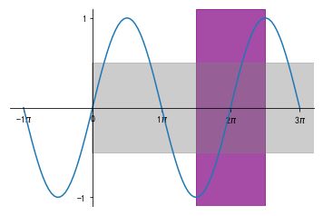

```python
# 高亮
xmin,xmax=-np.pi,3*np.pi
x=np.linspace(xmin,xmax,100)
y=np.sin(x)
plt.plot(x,y)
ax=plt.gca()
ax.spines['left'].set_position(('data',0))
ax.spines['bottom'].set_position(('data',0))
ax.spines['top'].set_visible(False)
ax.spines['right'].set_visible(False)
xticks=np.linspace(xmin,xmax,int((xmax-xmin)/np.pi+1)) # 第三个参数必须是整数，但实参为浮点数计算，要手动转换为int，否则给出警告：DeprecationWarning: object of type <class 'float'> cannot be safely interpreted as an integer.
plt.xticks(xticks,[str(int(i/np.pi))+('' if int(i/np.pi)==0 else '$\pi$') for i in xticks])
plt.yticks([-1,1])
plt.axvspan(1.5*np.pi,2.5*np.pi,color='purple',alpha=0.7)
plt.axhspan(-0.5,0.5,color='gray',xmin=0.27,alpha=0.4)
```

### 其他

#### arrow()用于绘制箭头

函数原型：`matplotlib.pyplot.arrow(x, y, dx, dy, **kwargs)`  
参数说明：绘制出一个从点(x, y)指向到点(x+dx, y+dy)的箭头。  
**kwargs**关键字参数用于设置FancyArrow属性

```python
plt.axis([0,10,0,10])
plt.arrow(1,1,2,2,fc='r',ec='b',width=0.2,head_width=2,head_length=5,linestyle='--',linewidth=2) # fc:facecolor,ec:edgecolor
```

[figure not shown]

#### imshow()用于显示图像（image）

函数原型：`matplotlib.pyplot.imshow(X, cmap=None, norm=None, aspect=None, interpolation=None, alpha=None, vmin=None, vmax=None, origin=None, extent=None, shape=None, filternorm=1, filterrad=4.0, imlim=None, resample=None, url=None, *, data=None, **kwargs)`  
参数说明：  
**x**参数：array-like（类似数组对象，如numpy中的ndarray、python原生列表及其嵌套等）或者PIL（Python Imaging Library）图像（Python图像处理标准库）。合法的数组形状：

- (m,n): an image with scalar data. The data is visualized using a colormap.
- (m,n,3): an image with RGB values (float or uint8).
- (m,n,4): an image with RGBA values (float or uint8), i.e. including transparency.

m,n决定了图像的行数和列数（图像的高、宽），RGB或RGBA颜色应为处于[0,1]范围的小数或者[0,255]范围的整数，超出范围的一律剪为边界值  
**cmap**参数：str or Colormap，Colormap将x的前两个维度的scalar data（标量数据）映射到色域中的颜色，缺省值为rcParams["image.cmap"]  
**aspect**参数：{'equal', 'auto'} or float, optional，控制轴域axes的纵横比，与图像显示特别相关，因为它可能会扭曲图像，即像素点不是方形的了。此参数是显式调用[Axes.set_aspect()](https://matplotlib.org/api/_as_gen/matplotlib.axes.Axes.set_aspect.html#matplotlib.axes.Axes.set_aspect)的快捷方式。

- 'equal': 确保宽高比为1，即像素点为方形（除非图像在创作时，像素点就不是方形的，这个时候再用方形像素点显示就不正确了，图像将被拉伸或压扁，using extent）
- 'auto': 轴axes保持固定，并调整像素点的纵横比，使数据适合于轴。 通常，这将导致非方形像素

若参数未给出，将使用[rcParams["image.aspect"]](https://matplotlib.org/tutorials/introductory/customizing.html#matplotlib-rcparams)(default: 'equal')  
**norm、vmin,vmax**参数：参见pcolor  
**origin**参数：上下翻转二维数组x，实际上就是沿着0轴（长为n）进行 x[i] 和 x[n-i-1] 位置的元素置换，可以使x[0][0]位于左上角或左下角，默认取值'upper'，当取'lower'时，x[0][0]将位于左下角  
**extent、其他参数**：看不懂

```
(-0.5, 255.5, 0.5, -0.5)
```

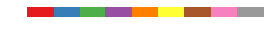

```python
# "Colormap Reference"一条小彩条的完整绘制过程（此处使用imshow()，当然使用plt.bar()也可以，另见）
plt.subplot(111)
plt.subplots_adjust(bottom=0.95,top=1)
a=np.linspace(0,1,256).reshape(1,256)
c=plt.get_cmap('Set1')
plt.imshow(a,cmap=c,aspect='auto')
plt.axis('off')
```

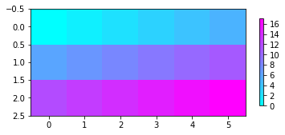

```python
a=np.arange(18).reshape(3,6)
plt.imshow(a,cmap='cool') # 从中我们可以看出，对于一个m*n的二维图像（3*6），它是怎么显示的（0轴对应y轴，1轴对应x轴）
plt.colorbar(shrink=0.5)
```

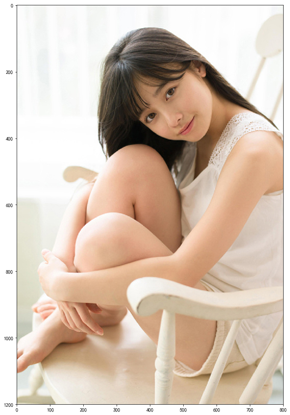

```python
# 结合PIL显示图像（最基本）
im=Image.open('./matplotlib/DB/image/40.jpg')
plt.figure(figsize=(15,15)) # 设置画布大小，可以实现放大和缩小图片的目的，或者使用dpi参数。过大的数值将导致图像失真
plt.imshow(im,aspect='equal') # 设置为auto观察，你将看到人物两边被拉伸开来
```

#### pcolor()绘制伪彩色图

函数原型：`matplotlib.pyplot.pcolor(*args, alpha=None, norm=None, cmap=None, vmin=None, vmax=None, data=None, **kwargs)`  
Call signature:  
`pcolor([X, Y,] C, **kwargs)`  
**x,y**参数可以将整个plot划分（方式：设置xticks(x)和yticks(y)，然后延长这些刻度即可）成诸多的矩形网格，每个格子是一个四边形区域，设其左下角位置坐标为(x[i],y[j])，那么这个格子将用于存放和显示一种颜色（c[i][j]所映射的颜色）  
**c**参数是一个二维的数组，其尺寸应比形状(len(y),len(x))还要大一圈，即(len(y)+1,len(x)+1)是最合理的（原因很简单，譬如说，5个格子我们需要6个刻度来标识啊），但是c的形状等于(len(y),len(x))也未尝不可，只不过c的最后一行和最后一列都将被省略，这些数据所映射的颜色将不会呈现出来。  
颜色映射：系统会将c中的数据映射到cmap中，cmap即color map对应着一个色域，matplotlib内置了众多的色域。映射的过程分为两步，首先通过数据转换类Normalize或者其子类实例将数据源c缩放至区间[0,1]范围内的小数，默认情况下是线性缩放。这个步骤被称为标准化。然后Colormap的实例就会将0-1范围内的小数转换成cmap中的颜色。整个过程是依据`data-> normalize-> map-to-color`的处理链  
**cmap**参数可以是字符串，也可以是Colormap的实例  
**vmin,vmax**参数：一个典型的应用场景是，譬如我们有一批数据，想要将其映射至cmap，并呈现出来以对数据进行可视化观察和分析，令人懊恼的是，映射之后，我们发现每一个数据的颜色都差不多，远着看甚至看不出数据有任何区别，我们的常识告诉我们，应该对数据进行“放大处理”，将微小的区别放大，区别不就显而易见了嘛。之所以这批数据的颜色相仿，是因为这批数据的大部分都映射到了cmap中的一个很小的区域，假设这批数据本身的最大值和最小值分别为min和max，而数据的主要集中区域可以为submin和submax（有：submin>>min,submax<<max）所囊括，于是我们人为地设置vmin=submin,vmax=submax，在未设置的默认情况下，vmin=min,vmax=max。于是经过标准化处理之后，数据的主要部分将分布于整个色域，不会出现之前集中于色域一小块范围的情况。另外，对于区间min-submin之内的数据标准化之后全部是0，区间submax-max之内的数据标准化之后全部是1（小于vmin阈值的数据全部使等于vmin，大于vmax阈值的数据全部使等于vmax）。  
注意：pcolor()对于大型数组来说可能非常慢。在大多数情况下，您应该使用类似但更快的pcolormesh()  
其他参数见[文档](https://matplotlib.org/api/_as_gen/matplotlib.pyplot.pcolor.html#matplotlib.pyplot.pcolor)

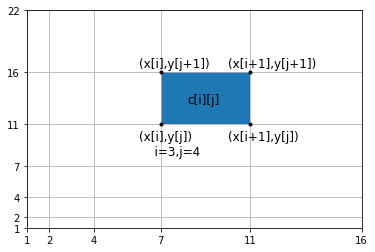

```python
x=[1,2,4,7,11,16]
y=x+[22]
plt.xticks(x)
plt.yticks(y)
plt.grid()
plt.axis([1,16,1,22])
plt.fill([7,11,11,7],[11,11,16,16])
plt.plot([7,7,11,11],[11,16,11,16],marker='.',color='black',linestyle='')
plt.annotate('(x[i],y[j])\n    i=3,j=4',(6,8),fontsize=12)
plt.annotate('c[i][j]',(8.2,13),fontsize=12)
plt.annotate('(x[i],y[j+1])',(6,16.5),fontsize=12)
plt.annotate('(x[i+1],y[j])',(10,9.5),fontsize=12)
plt.annotate('(x[i+1],y[j+1])',(10,16.5),fontsize=12)
```

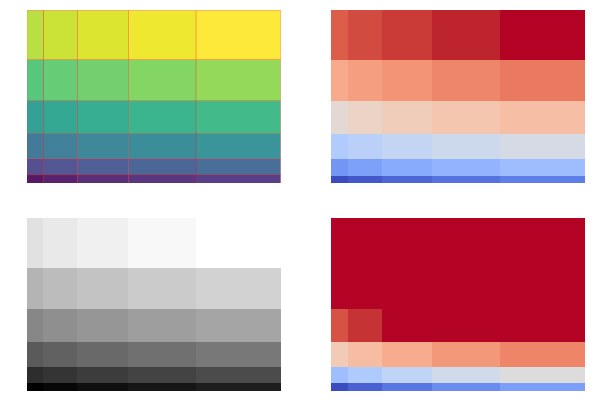

```python
x=[1,2,4,7,11,16]
y=x+[22]
fig,ax=plt.subplots(2,2,sharey=True,sharex=True)
fig.set_figwidth(10)
fig.set_figheight(7)
ax[0,0].set_xticks(x)
ax[0,1].set_yticks(y)
# 关闭全部轴刻度
for i in [0,1]:
    for j in [0,1]:
        ax[i,j].axis('off')
# 替代方案
'''
for i in ax.flat:
    i.set_axis_off()
'''
c=np.arange(len(x)*len(y)).reshape(len(y),len(x))
ax[0,0].pcolor(x,y,c,edgecolor='red',alpha=0.9)
ax[0,1].pcolor(x,y,c,cmap='coolwarm')
ax[1,0].pcolor(x,y,c,cmap='gray')
ax[1,1].pcolor(x,y,c,cmap='coolwarm',vmin=0,vmax=20)
```

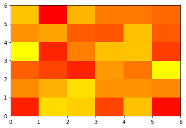

```python
c=np.random.rand(36).reshape(6,6)
plt.pcolor(c,cmap='autumn')
```

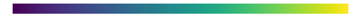

```python
# 这里还没有看，代码来源于网络
# 如何只保留x轴的刻度，但不要y轴的？如果不行，那就用colorbar
grad=np.linspace(0,1,256)
grad=np.vstack((grad,grad))
plt.figure(figsize=(10,0.3))
ax=plt.subplot()
plt.xticks([0,100,250],[0,100,251])
plt.axis('off')
ax.imshow(grad,aspect='auto')
```

vmin和vmax参数说明：

[figure not shown]

#### [pcolormesh()](https://matplotlib.org/api/_as_gen/matplotlib.pyplot.pcolormesh.html#matplotlib.pyplot.pcolormesh)绘制伪彩色图（相较于pcolor()，它更快更优先，在使用中，总是首选pcolormesh()）

函数原型：`matplotlib.pyplot.pcolormesh(*args, alpha=None, norm=None, cmap=None, vmin=None, vmax=None, shading='flat', antialiased=False, data=None, **kwargs)`  
Call signature:  
`pcolor([X, Y,] C, **kwargs)`  
参数参见pcolor()  
与pcolor()之间的区别：  
主要区别在于创建的对象和内部数据处理：当pcolor()返回PolyCollection时，pcolormesh()返回QuadMesh。后者更专业于特定目的，因此更快。它应该几乎总是首选。...  
靠，鬼读得懂!  
Both methods are used to create a pseudocolor plot of a 2-D array using quadrilaterals.

The main difference lies in the created object and internal data handling: While pcolor returns a PolyCollection, pcolormesh returns a QuadMesh. The latter is more specialized for the given purpose and thus is faster. It should almost always be preferred.

There is also a slight difference in the handling of masked arrays. Both pcolor and pcolormesh support masked arrays for C. However, only pcolor supports masked arrays for X and Y. The reason lies in the internal handling of the masked values. pcolor leaves out the respective polygons from the PolyCollection. pcolormesh sets the facecolor of the masked elements to transparent. You can see the difference when using edgecolors. While all edges are drawn irrespective of masking in a QuadMesh, the edge between two adjacent masked quadrilaterals in pcolor is not drawn as the corresponding polygons do not exist in the PolyCollection.

Another difference is the support of Gouraud shading in pcolormesh, which is not available with pcolor.

#### set_cmap()设置默认的color map

函数原型：`matplotlib.pyplot.set_cmap(cmap)`  
该设置适用于当前图像（current image）。参数cmap必须是一个Colormap实例，或者一个已注册的（matplotlib内置）colormap名称（譬如'autumn'）。参见[matplotlib.cm.register_cmap()](https://matplotlib.org/api/cm_api.html#matplotlib.cm.register_cmap)和[matplotlib.cm.get_cmap()](https://matplotlib.org/api/cm_api.html#matplotlib.cm.get_cmap).

#### get_cmap()获取指定的color map

函数原型：`matplotlib.cm.get_cmap(name=None, lut=None)`  
获取一个colormap实例，如果name为None，则默认为rc值。使用[register_cmap()](https://matplotlib.org/api/cm_api.html#matplotlib.cm.register_cmap)添加的colormaps（颜色映射）优先于内置的colormaps。如果name是一个Colormap实例，那么它就是函数返回值  
If lut is not None it must be an integer giving the number of entries desired in the lookup table, and name must be a standard mpl colormap name.（不懂）

##### Colormap Reference

Reference for colormaps included with Matplotlib.  
A reversed version of each of these colormaps is available by appending _r to the name, e.g., viridis_r.  
See [Choosing Colormaps in Matplotlib](https://matplotlib.org/tutorials/colors/colormaps.html) for an in-depth discussion about colormaps, including colorblind-friendliness.

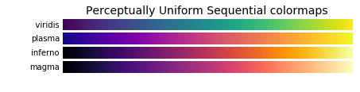

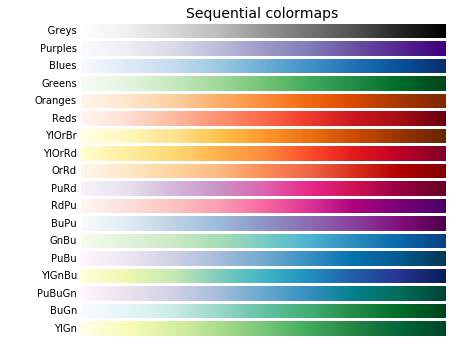

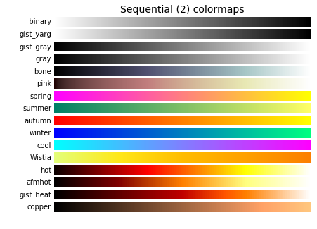

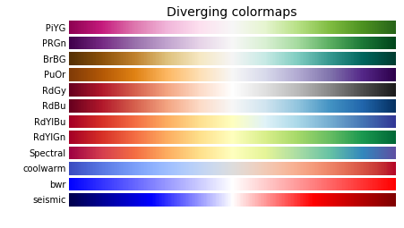

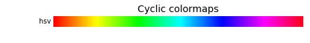

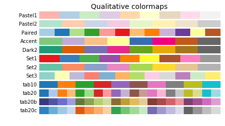

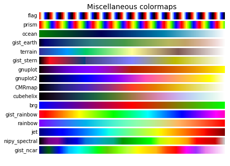

```python
# registed cmap
cmaps = [('Perceptually Uniform Sequential', [
            '            viridis', 'plasma', 'inferno', 'magma']),
         ('Sequential', [
            '             Greys', 'Purples', 'Blues', 'Greens', 'Oranges', 'Reds',
            'YlOrBr', 'YlOrRd', 'OrRd', 'PuRd', 'RdPu', 'BuPu',
            'GnBu', 'PuBu', 'YlGnBu', 'PuBuGn', 'BuGn', 'YlGn']),
         ('Sequential (2)', [
            '           binary', 'gist_yarg', 'gist_gray', 'gray', 'bone', 'pink',
            'spring', 'summer', 'autumn', 'winter', 'cool', 'Wistia',
            'hot', 'afmhot', 'gist_heat', 'copper']),
         ('Diverging', [
            '              PiYG', 'PRGn', 'BrBG', 'PuOr', 'RdGy', 'RdBu',
            'RdYlBu', 'RdYlGn', 'Spectral', 'coolwarm', 'bwr', 'seismic']),
         ('Cyclic', ['                hsv']),
         ('Qualitative', [
            '          Pastel1', 'Pastel2', 'Paired', 'Accent',
            'Dark2', 'Set1', 'Set2', 'Set3',
            'tab10', 'tab20', 'tab20b', 'tab20c']),
         ('Miscellaneous', [
            'flag', 'prism', 'ocean', 'gist_earth', 'terrain', 'gist_stern',
            'gnuplot', 'gnuplot2', 'CMRmap', 'cubehelix', 'brg',
            'gist_rainbow', 'rainbow', 'jet', 'nipy_spectral', 'gist_ncar'])]
# 为了让它们对齐，我容易吗我？有没有办法解决？（去掉以上某些字符串中多余的空格，你就明白了，太影响审美了）

gradient = np.linspace(0, 1, 256)
gradient = np.vstack((gradient, gradient))


def plot_color_gradients(cmap_category, cmap_list):
    # Create figure and adjust figure height to number of colormaps
    nrows = len(cmap_list)
    figh = 0.35 + 0.15 + (nrows + (nrows-1)*0.1)*0.22
    fig, axes = plt.subplots(nrows=nrows, figsize=(6.4, figh))
    fig.subplots_adjust(top=1-.35/figh, bottom=.15/figh, left=0.2, right=0.99)

    axes=axes if isinstance(axes,np.ndarray) else np.array([axes])
    axes[0].set_title(cmap_category + ' colormaps', fontsize=14)

    for ax, name in zip(axes, cmap_list):
        ax.imshow(gradient, aspect='auto', cmap=plt.get_cmap(name.strip()))
        ax.text(-.01, .5, name, va='center', ha='right', fontsize=10,
                transform=ax.transAxes)

    # Turn off *all* ticks & spines, not just the ones with colormaps.
    for ax in axes:
        ax.set_axis_off()


for cmap_category, cmap_list in cmaps:
    plot_color_gradients(cmap_category, cmap_list)
```

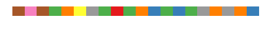

[figure not shown]

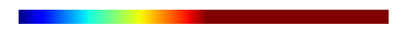

```python
# 要使用以上的内置cmap：plt.cm.<cmap's name>([...]) 可获取color map的一部分颜色映射
# [...]序列元素取值一般取0-1范围之内的小数，以上小彩条的起点就是0，终点就是1，譬如取0.5就是中间的颜色，取0.25就是1/4处的颜色，这样对照着彩条，我们就可以取到合适的颜色
# 要获取整个color map: get_cmap("cmap's name")
colors=plt.cm.Set1(np.random.randint(0,10,20))
# 颜色展示（彩条）
def colorsBar(colors):
    '''Show all colors via bar plot'''
    n_colors=len(colors)
    index=np.linspace(0,1,n_colors)
    width=index[1]-index[0]
    plt.figure(figsize=(7.5,0.3))
    plt.bar(index,1,color=colors,width=width)
    plt.xlim(0-0.5*width,1+0.5*width)
    plt.axis('off')
colorsBar(colors)
colorsBar(plt.cm.gist_ncar(np.random.randint(0,300,100))) # 当然非0-1也是可以的，会被标准化至0-1空间
colorsBar(plt.cm.jet(np.arange(500)))
```

#### savefig()保存当前图像figure

函数原型：`matplotlib.pyplot.savefig(*args, **kwargs)`  
Call signature:  
`savefig(fname, dpi=None, facecolor='w', edgecolor='w', orientation='portrait', papertype=None, format=None, transparent=False, bbox_inches=None, pad_inches=0.1, frameon=None, metadata=None)`  
The output formats available depend on the backend being used.（可用的输出文件格式依赖于当前使用的的后端）  
参数说明：  
**fname**参数：str or file-like object，一个字符串，包含指向文件的路径，或类似于python file的对象，或者可能是一些后端（backend）相关的对象，如 PdfPages。如果文件格式format为None，fname为文件名字符串，则从文件名的扩展名推断出输出格式。如果文件名没有扩展名，则使用rcparams[“savefig.format”]。如果fname不是字符串，请记住指定format参数以确保使用正确的后端。  
其它参数：  
**dpi**参数：None or scalar > 0 or 'figure'，设置分辨率，单位为点数每英寸（dots per inch），如果为None，默认为rcParams["savefig.dpi"]。如果取'figure'，则使用图像figure的dpi值  
**quality**参数：None or 1 <= scalar <= 100，图像质量，取值从1（最差）到95（最好）。仅当格式为JPG或JPEG时适用，否则忽略。如果取值None，则默认为rcparams[“savefig.jpeg_quality”]（默认为95）。应避免使用大于95的值；100 completely disables the JPEG quantization stage.（What?）  
**facecolor**参数：color spec or None, optional，The facecolor of the figure; if None, defaults to rcParams["savefig.facecolor"].  
**edgecolor**参数：color spec or None, optional，The edgecolor of the figure; if None, defaults to rcParams["savefig.edgecolor"]  
**orientation**参数：{'landscape', 'portrait'}，Currently only supported by the postscript backend.  
**papertype**参数：str，可选值：'letter', 'legal', 'executive', 'ledger', 'a0' through 'a10', 'b0' through 'b10'. Only supported for postscript output.  
**format**参数：str，可选值：后端支持的文件扩展名之一，大多数后端支持 png, pdf, ps, eps 和 svg。  
下面我就读不懂了：  
**transparent**参数：bool，If True, the axes patches will all be transparent; the figure patch will also be transparent unless facecolor and/or edgecolor are specified via kwargs. This is useful, for example, for displaying a plot on top of a colored background on a web page. The transparency of these patches will be restored to their original values upon exit of this function.  
**frameon**参数：bool，If True, the figure patch will be colored, if False, the figure background will be transparent. If not provided, the rcParam 'savefig.frameon' will be used.  
**bbox_inches**参数：str or Bbox, optional，Bbox in inches. Only the given portion of the figure is saved. If 'tight', try to figure out the tight bbox of the figure. If None, use savefig.bbox  
**pad_inches**参数：scalar, optional，Amount of padding around the figure when bbox_inches is 'tight'. If None, use savefig.pad_inches  
**bbox_extra_artists**参数：list of Artist, optional，A list of extra artists that will be considered when the tight bbox is calculated.  
**metadata**参数：dict, optional，Key/value pairs to store in the image metadata. The supported keys and defaults depend on the image format and backend:

- 'png' with Agg backend: See the parameter metadata of print_png.
- 'pdf' with pdf backend: See the parameter metadata of PdfPages.
- 'eps' and 'ps' with PS backend: Only 'Creator' is supported.

#### 修改matplotlib默认（全局）配置（毋执行之）

譬如轴域的背景色、图像保存时的fc：  
`plt.rcParams['axes.facecolor']='green'`  
`plt.rcParams['savefig.facecolor']='white'`

#### plot_dates()使用包含日期的数据绘图

函数原型：`matplotlib.pyplot.plot_date(x, y, fmt='o', tz=None, xdate=True, ydate=False, *, data=None, **kwargs)`  
类似于plot()，本函数可用于绘制线形图和散点图，区别在于，plot_dates()的轴标签的格式取决于xdate和ydate。  
看不懂

#### plotfile()使用文件中数据绘图

函数原型：`matplotlib.pyplot.plotfile(fname, cols=(0, ), plotfuncs=None, comments='#', skiprows=0, checkrows=5, delimiter=', ', names=None, subplots=True, newfig=True, **kwargs)`  
看不懂

### 柱状图、饼状图、散点图等

#### bar()绘制柱状图

函数原型：`matplotlib.pyplot.bar(x, height, width=0.8, bottom=None, *, align='center', data=None, **kwargs)`  
参数说明：  
将这些bars（柱）以指定的对齐方式（align）分别置于x坐标处，它们的尺寸由height和width（缺省为0.8）指出，其基线（柱bars的底部所在水平线）默认为0（水平线：y=0）。x、height、width和bottom都可以是单个标量适用于全部bars，也可以是长为N（柱的个数）的序列，用来为每一个bar提供属性值。  
**align**参数：{'center', 'edge'}, optional, default: 'center'  
'center': 柱的中心位于x位置处  
'edge': 柱的左边缘与x对齐  
要使柱的右边缘与x对齐，传递负的width值并置align='edge'  
其他参数：  
**color**：scalar or array-like, optional，（以单一颜色）设置全部bars的face color或为每一个bar单独设置（不同的颜色）  
**edgecolor**：scalar or array-like, optional，设置全部bars的edge color或为每一个bar单独设置  
**linewidth**：scalar or array-like, optional，设置全部bars的edge line width或为每一个bar单独设置，当为0时，不绘制边线  
**tick_label**：string or array-like, optional，设置全部bars的label标签或为每一个bar单独设置，缺省为None，使用数字标签（刻度）  
误差（另见errorbar()）：  
**xerr,yerr**：scalar or array-like of shape(N,) or shape(2,N), optional  
xerr可以跳过，几乎用不到，看一下yerr就行，可以描述柱状图在y轴取值的误差（浮动）范围，或者用于描述均值与标准差、均值与标准误差、置信区间（一般用errorbar()）。  
单个标量scalar将适用于全部bar，每个bar的顶部在垂直方向上+/-一个scalar；形状(N,)的序列将为每个bar单独设置+/-的值；形状(2,N)的数组将为每个bar单独设置用于+的值以及用于-的值。  
**ecolor**参数：scalar or array-like, optional，设置全部error bars的颜色或为每一个bar单独设置，缺省为黑色  
**capsize**参数：我实在是无法描述这是个什么玩意儿，只要知道它接受一个标量，含义为长度，单位为point，譬如取10，就是10个像素点那么长，缺省时，取自[rcParams["errorbar.capsize"]](https://matplotlib.org/tutorials/introductory/customizing.html#matplotlib-rcparams)，具体见实验  
**error_kw**参数接受一个字典，就是对上述一系列参数进行一个打包，传递给errorbar()，其中的ecolor键或capsize键具有比在外面设置的相同关键字参数更高的优先级。  
**log**参数：bool, optional, default: False，y轴刻度以对数计量  
**orientation**参数：{'vertical', 'horizontal'}, optional，控制绘制的柱形图是垂直还是水平的，但是不被推荐，若希望绘制水平方向的柱状图，应使用barh()  
[其他](https://matplotlib.org/api/_as_gen/matplotlib.pyplot.bar.html#matplotlib.pyplot.bar)关键字参数  
返回值：  
返回一个容器对象，BarContainer：Container with all the bars and optionally errorbars.（用help或者内省查看了一下，容器中的元素即bar是拥有label标签属性的，可以用于设置legend，通过setp()来设置）

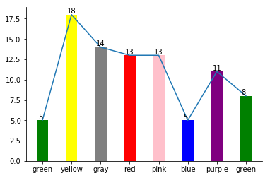

```python
# 随机数柱状图
n=8# 试着赋值100,，理论上允许绘制任意数量的bar
bars=[2*i+1 for i in range(n)] # 设置每个bar所在的刻度
colors=['red','blue','purple','green','gray','yellow','pink'] # 很多颜色，可以超出bars的个数
np.random.shuffle(colors)
'''
if n>len(colors):
    colors+=[colors[-1]]*(n-len(colors))
'''
while n>len(colors): # 当n很大，不断重复颜色
    colors+=colors[:n-len(colors)]
values=np.random.randint(5,20,len(bars))
plt.bar(bars,values,color=colors,tick_label=colors[:len(bars)])
for i in range(n):
    plt.annotate('{0}'.format(values[i]),(bars[i]-0.3,values[i]+0.15))
ax=plt.gca()
ax.spines['top'].set_visible(False)
ax.spines['right'].set_visible(False)
plt.plot(bars,values)
```

```
Text(2.5,4.8,'capsize parament')
```

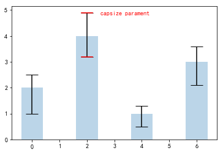

```python
# 四个柱的取值分别为2、4、1、3，第一个柱的浮动范围为[2-1,2+0.5]、第二个柱的浮动范围为[4-0.8,4+0.9]、第三个柱的浮动范围为[1-0.5,1+0.3]、第四个柱的浮动范围为[3-0.9,3+0.6]
plt.bar([0,2,4,6],[2,4,1,3],yerr=[[1,0.8,0.5,0.9],[0.5,0.9,0.3,0.6]],capsize=10,alpha=0.3)
plt.plot([2-0.2,2+0.2],[4.9,4.9],color='red')
plt.plot([2-0.2,2+0.2],[3.2,3.2],color='red')
plt.annotate('capsize parament',(2.5,4.8),color='red')
```

```
 <a list of 5 Text xticklabel objects>)
```

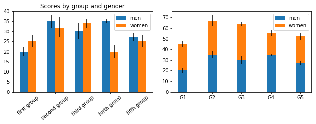

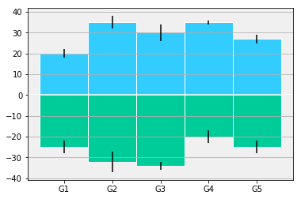

```python
n_groups=5
means_men=(20,35,30,35,27) # 含义：均值
std_men=(2,3,4,1,2) # 含义：标准差
means_women=(25,32,34,20,25)
std_women=(3,5,2,3,3)
barwidth=0.3
index_men=np.arange(n_groups)
index_women=index_men+barwidth
# 绘制1
plt.subplot(121)
plt.bar(index_men,means_men,width=-barwidth,yerr=std_men,align='edge',label='men') # 为全部的蓝色bar设置同一的label标签，如果我们一次绘制的bars颜色各不相同，是否可以逐一设置label呢，是可以的，见"polar bar"
plt.bar(index_women,means_women,width=-barwidth,yerr=std_women,align='edge',label='women')
plt.legend()
plt.xticks(index_men,['first group','second group','third group','forth group','fifth group'],rotation=40)
plt.title('Scores by group and gender')
# 绘制2（bottom参数）
plt.subplot(122)
plt.bar(index_men,means_men,width=-barwidth,yerr=std_men,label='men',tick_label=['G1','G2','G3','G4','G5'])
plt.bar(index_men,means_women,width=-barwidth,yerr=std_women,bottom=means_men,label='women')
plt.legend()
# 调整子图大小和间距
plt.tight_layout(rect=(0,0,1.5,0.9))
# 绘制3
plt.subplots() # 准备新的figure（最大的画布单位，试着去掉此句看看结果）
plt.bar(index_men,means_men,width=1,yerr=std_men,label='men',color=plt.cm.cool(0.2),edgecolor='w')
plt.bar(index_men,[-i for i in means_women],width=1,yerr=std_women,label='women',color=plt.cm.winter(0.8),edgecolor='w')
plt.gca().set_facecolor('#F0F0F0')
plt.grid(axis='y')
plt.axhline(0,color='w')
# 靠，为什么这两种方法都出错？？？
# plt.gca().set_xticklabels(['G1','G2','G3','G4','G5']) # plt.setp(plt.gca().xticklabels,['G1','G2','G3','G4','G5'])
plt.xticks(index_men,['G1','G2','G3','G4','G5'])
```

##### [Pie chart on polar axis](https://matplotlib.org/gallery/pie_and_polar_charts/polar_bar.html#sphx-glr-gallery-pie-and-polar-charts-polar-bar-py)（Demo of bar plot on a polar axis）

A different appearance of bar graph.

```
<Container object of 1 artists>
```

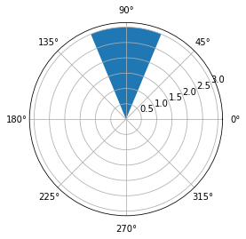

```python
plt.subplot(111,projection='polar') # 准备，创建一个极坐标画板，默认创建的是直角坐标画板
plt.bar(0.5*np.pi,3,width=0.25*np.pi) # 开始绘制，参数同直角系，此语句结果：在1/2π处（居中）绘制一个扇形，弧度由width参数指定，即1/4π ，扇形母线长度由height参数指定（第二个位置参数）指定，此处为3
```

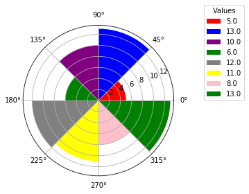

```python
# 绘制一批数据在极坐标下的“柱状图”（polar bar）
data=np.random.randint(5,15,8) # 试着修改第三个参数
# 要绘制polar bar，首先准备好bar index、bar height、bar width、bar color，前三项对应在极坐标下，就是：theta index、wedge radius、wedge radian
radian=2*np.pi/len(data)
radius=data
index=[(i+0.5)*radian for i in range(len(data))]
colors=['red','blue','purple','green','gray','yellow','pink']
while len(data)>len(colors):
    colors+=colors[:len(data)-len(colors)]
while colors[0]==colors[-1] or colors[-1]==colors[-2]:
    colors[-1]=np.random.choice(colors) # 防止两个相邻的楔形颜色相同
# 绘制
plt.subplot(111,projection='polar')
bars=plt.bar(index,radius,radian,color=colors)
# 通过内省为每一个颜色不同的bar设置对应的标签（我这里存在颜色相同的bar，所以仅作示例，教导如何使用罢了）
for index,bar in enumerate(bars):
    plt.setp(bar,label='%2.1f'%data[index])
plt.legend(loc=(1.2,0.5),title='Values')
```

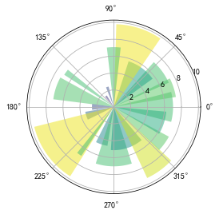

```python
# 绘制matplotlib经典标志
n=20 # 设置柱的个数
# Fixing random state for reproducibility
np.random.seed(19680801) # 试着填入其它任意整数，譬如你的生日
# 三大参数
theta=np.linspace(0,2*np.pi,n,endpoint=False)
radius=np.random.rand(n)*10
#width=np.pi/n*1.2*2
width=np.pi/4*np.random.rand(n)
# 绘制polar bar
plt.subplot(111,projection='polar')
bars=plt.bar(theta,radius,width)

# Use custom colors and opacity（未仔细看）
for r, bar in zip(radius, bars):
    bar.set_facecolor(plt.cm.viridis(r / 10.))
    bar.set_alpha(0.5)
```

#### barh()生成水平柱状图

函数原型：`matplotlib.pyplot.barh(y, width, height=0.8, left=None, *, align='center', **kwargs)`  
和bar()几乎没有任何区别，试想一下，将直角坐标系的x轴和y轴名字调换一下，bar()不就变成了barh()嘛

```
<Container object of 4 artists>
```

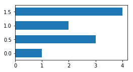

```python
plt.figure(figsize=(4,2))
plt.barh(np.arange(0,2,0.5),[1,3,2,4],0.3)
```

#### pie()绘制饼状图

函数原型：`matplotlib.pyplot.pie(x, explode=None, labels=None, colors=None, autopct=None, pctdistance=0.6, shadow=False, labeldistance=1.1, startangle=None, radius=None, counterclock=True, wedgeprops=None, textprops=None, center=(0, 0), frame=False, rotatelabels=False, *, data=None)`  
参数说明：  
pie()绘制数组x的饼图，默认情况下“饼”的半径为1，即总面积为π。每个楔形（扇形）的面积由数组元素x[i]与数组x的总和（sum(x)）的比值决定，于是有：x_rate=x/sum(x)，数组x_rate中存放的即是每个楔形面积与“饼”总面积的比值，这一过程称为“标准化”。但当sum(x)<=1时，每个楔形面积与“饼”总面积的比值就是x[i]，此时毋须再标准化，特别地，当sum(x)<1时，“饼”不完整，存在空的楔形区域。  
楔形是按照逆时针顺序绘制的，默认情况下是从x轴开始  
**explode**参数：array-like, optional, default: None，每个楔形偏离“饼”心的程度，是一个分数。距离产生美，可以用于凸显某些楔形部分  
**labels**参数：list, optional, default: None，为每一个楔形设置标签  
**colors**参数：array-like, optional, default: None，为每一个楔形设置颜色  
**autopct**参数：None (default), string, or function, optional，用于显示每个楔形所占比例，其置于楔形内部，默认不显示。它可以是一个（格式）字符串（譬如：'%d%%','%2.1f%%','%s%%'），也可以是函数。  
**pctdistance**参数：float, optional, default: 0.6，设置autopct在楔形中的位置，默认值表示其显示的位置距离楔形的尖端为0.6（百分比，而默认楔形的母线长度即“饼”的半径就是1），当autopct为None时，该参数无效  
**shadow**参数：bool, optional, default: False，是否为饼状图绘制阴影  
**labeldistance**参数：float, optional, default: 1.1，描述楔形标签label与楔形尖端的距离  
**startangle**参数：float, optional, default: None，楔形绘制的起点，默认为x-axis，此时startangle=0，角度沿逆时针递增，再次回到x-axis时，角度增至360度  
**radius**参数：float, optional, default: None，“饼”的半径  
**counterclock**参数：bool, optional, default: True，楔形绘制的方向，默认是逆时针，当取False时，为顺时针  
**wedgeprops**参数：dict, optional, default: None，一个描述构成饼状图的楔形对象的字典参数，譬如wedgeprops={'linewidth':3}，用于设置楔形边框线的宽度，另外width是一个神奇的属性，它用于绘制“环形饼”，其他属性自行查阅。  
**textprops**参数：dict, optional, default: None，一个描述饼图中Text文本属性的字典参数  
**center**参数：list of float, optional, default: (0, 0)，Center position of the chart. Takes value (0, 0) or is a sequence of 2 scalars.  
**frame**参数：bool, optional, default: False，为True则绘制出轴域axes框架  
**rotatelabels**参数：bool, optional, default: False，为True则旋转每一个楔形的标签至所在楔形角度  
返回值：  
**patches**: list  
全部的楔形对象（A sequence of matplotlib.patches.Wedge instances）  
**texts**: list  
全部的labels标签对象（是Text文本对象）（A list of the label matplotlib.text.Text instances）  
**autotexts**: list  
全部的autopct对象（也是Text文本）（A list of Text instances for the numeric labels. This will only be returned if the parameter autopct is not None.） 注意： 如果figure和axes是方形，或者axes的aspect参数取'equal'，则饼图可能看起来最佳。此方法将轴的纵横比设置为“equal”。可以使用Axes.set_aspect()控制axes纵横比。  
除了使用上述的关键字参数，还支持一个名为‘data’的关键字参数，该参数可用于替换以下参数：'colors', 'explode', 'labels', 'x'，这样的'data'必须能够通过`data[<arg>]`（譬如data['colors']）的方式访问，并且支持语法：`<arg> in data`

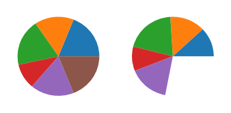

```python
x=np.random.randint(5,15,6)
plt.subplot(121)
plt.pie(x)
plt.subplot(122)
plt.pie([0.12,0.14,0.2,0.1,0.16]) # 存在空缺楔形部分的饼图
plt.tight_layout(rect=(0,0,0.8,0.6)) # 当子图宽了或者扁了、大了或者小了的时候，进行修“正”
```

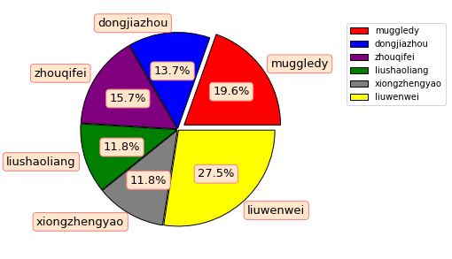

```python
x=np.random.randint(5,15,6)
explode=[0.08,0.01,0.01,0.01,0.01,0.01]
labels=['muggledy','dongjiazhou','zhouqifei','liushaoliang','xiongzhengyao','liuwenwei']
colors=['red','blue','purple','green','gray','yellow','pink']
autopct='%2.1f%%' # 等同于函数：autopct=lambda x:'%2.1f%%'%x
plt.figure(figsize=(5,5))
plt.pie(x,explode=explode,labels=labels,colors=colors,autopct=autopct,wedgeprops=dict(edgecolor='black',linewidth=1),textprops=dict(color='black',fontsize=13,bbox=dict(boxstyle="round",ec=(1.,0.5,0.5),fc=(1.,0.9,0.8)))) # 感觉好难看~
#plt.gca().set_aspect('equal') # 我怎么没看出任何效果呢？ # ax.set(aspect="equal", title='Pie')
plt.legend(loc=(1.2,0.6))
```

##### [Nested pie charts](https://matplotlib.org/gallery/pie_and_polar_charts/nested_pie.html#sphx-glr-gallery-pie-and-polar-charts-nested-pie-py)（双层嵌套环形饼图）

```
 [Text(-1.1, 1.3471114790620887e-16, '')])
```

[figure not shown]

```python
# 楔形对象的width属性：绘制圆环饼
plt.pie([1],wedgeprops=dict(width=0.5))
```

```
Text(-0.13,-0.08,'PIE')
```

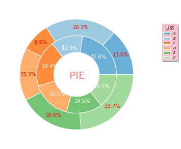

```python
# 根据上面的“环”，我们大概有了思路，绘制两个这样的环，通过设置radius饼半径即可将另一个小环嵌套在大环内（you can accomplish the same output by using a bar plot on axes with a polar coordinate system.参见"Pie chart on polar axis"）
out_ring=np.random.randint(5,15,6)
nested_ring=np.random.randint(5,15,6)
# 参数设置
labels=['A','B','C','D','E','F']
out_radius=1
nested_radius=0.7
out_width=out_radius-nested_radius
nested_width=out_width #
out_pctdistance=out_radius-0.5*out_width
nested_pctdistance=nested_radius
fmt='%2.1f%%'
# 颜色（尚未仔细看）
cmap=plt.get_cmap("tab20c")
colors=cmap(np.array([1,2,5,6,9,10]))
# 开始绘制
plt.figure(figsize=(5,5))
# 外环
wedges1,wedge_labels1,wedge_autopcts1=plt.pie(out_ring,wedgeprops=dict(width=out_width,ec='w'),radius=out_radius,colors=colors,autopct=fmt,pctdistance=out_pctdistance)
# 内环
*_,wedge_autopcts2=plt.pie(nested_ring,wedgeprops=dict(width=nested_width,ec='w'),radius=nested_radius,colors=colors,autopct=fmt,pctdistance=nested_pctdistance) # 解构，赋值号左边只能有一个*号，靠，我居然又忘了
# 标签（legend）
plt.legend(wedges1,labels,loc=(1.1,0.6),prop=dict(size='x-small',family='sans-serif',style='oblique'),shadow=True,facecolor='pink',title='List')
# （内省）设置Text颜色属性
plt.setp(wedge_autopcts1,color='r')
plt.setp(wedge_autopcts2,color='w')
# others
plt.annotate('PIE',(-0.13,-0.08),fontsize=20,alpha=0.5,color='r')
```